# Iris_Classification

### NAME: DISHA TANDON

## Getting the data & making necessary changes

This section of the code starts by importing the necessary libraries for data manipulation, visualization, and machine learning. The pandas library is used to handle the dataset, while seaborn and matplotlib are employed to create visualizations. Numpy is imported for numerical operations, and scikit-learn provides functions for label encoding, scaling, splitting the dataset, and applying machine learning models like the decision tree classifier.

The Iris dataset is then loaded into a pandas DataFrame using pd.read_csv('Iris.csv'), and the first few rows of the dataset are displayed using Iris.head().

This shows the sepal and petal measurements for various Iris species (e.g., Iris-setosa). The code prepares the data for further analysis by confirming the dataset's structure and cleanliness. The next steps will involve preprocessing, model training, and performance evaluation, as suggested by the imported functions for model splitting and evaluation.

```python
import pandas as pd
import seaborn as sns
import numpy as np
import matplotlib.pyplot as plt
from sklearn.preprocessing import LabelEncoder
from sklearn.preprocessing import StandardScaler #for scaling the data
from sklearn.model_selection import train_test_split #to split the dataset for training and testing
from sklearn.tree import DecisionTreeClassifier #for using Decision Tree Algoithm
from sklearn.tree import plot_tree
from sklearn.metrics import accuracy_score, confusion_matrix
from sklearn.model_selection import cross_val_score
from sklearn.model_selection import GridSearchCV
from sklearn.model_selection import cross_validate
```

```python
Iris = pd.read_csv('Iris.csv')
Iris.head()
```

|  | Id | SepalLengthCm | SepalWidthCm | PetalLengthCm | PetalWidthCm | Species |
| --- | --- | --- | --- | --- | --- | --- |
| 0 | 1 | 5.1 | 3.5 | 1.4 | 0.2 | Iris-setosa |
| 1 | 2 | 4.9 | 3.0 | 1.4 | 0.2 | Iris-setosa |
| 2 | 3 | 4.7 | 3.2 | 1.3 | 0.2 | Iris-setosa |
| 3 | 4 | 4.6 | 3.1 | 1.5 | 0.2 | Iris-setosa |
| 4 | 5 | 5.0 | 3.6 | 1.4 | 0.2 | Iris-setosa |

```python
# Renaming the columns
Iris.rename(columns={
    'SepalLengthCm': 'Sepal.Length','SepalWidthCm': 'Sepal.Width', 'PetalLengthCm': 'Petal.Length', 'PetalWidthCm': 'Petal.Width'
}, inplace=True)
Iris.head()
```

|  | Id | Sepal.Length | Sepal.Width | Petal.Length | Petal.Width | Species |
| --- | --- | --- | --- | --- | --- | --- |
| 0 | 1 | 5.1 | 3.5 | 1.4 | 0.2 | Iris-setosa |
| 1 | 2 | 4.9 | 3.0 | 1.4 | 0.2 | Iris-setosa |
| 2 | 3 | 4.7 | 3.2 | 1.3 | 0.2 | Iris-setosa |
| 3 | 4 | 4.6 | 3.1 | 1.5 | 0.2 | Iris-setosa |
| 4 | 5 | 5.0 | 3.6 | 1.4 | 0.2 | Iris-setosa |

Next, I decided to rename the columns to make them more readable and consistent. I used the .rename() function from pandas, changing 'SepalLengthCm' to 'Sepal.Length', 'SepalWidthCm' to 'Sepal.Width', and so on. The new names are shorter and more intuitive, which makes it easier to reference them throughout the rest of my analysis. I used the inplace=True parameter so that the changes were applied directly to the original DataFrame without needing to create a copy.

```python
# Remove "Iris-" from the Species column
Iris['Species'] = Iris['Species'].str.replace('Iris-', '', regex=False)
Iris.head()
```

|  | Id | Sepal.Length | Sepal.Width | Petal.Length | Petal.Width | Species |
| --- | --- | --- | --- | --- | --- | --- |
| 0 | 1 | 5.1 | 3.5 | 1.4 | 0.2 | setosa |
| 1 | 2 | 4.9 | 3.0 | 1.4 | 0.2 | setosa |
| 2 | 3 | 4.7 | 3.2 | 1.3 | 0.2 | setosa |
| 3 | 4 | 4.6 | 3.1 | 1.5 | 0.2 | setosa |
| 4 | 5 | 5.0 | 3.6 | 1.4 | 0.2 | setosa |

I simplified the 'Species' column by removing the prefix 'Iris-' from each value. I did this with the .str.replace() function, replacing 'Iris-' with an empty string. For example, 'Iris-setosa' became just 'setosa'. I set regex=False since I didn’t need any pattern matching for this simple replacement. This step made the species names cleaner and easier to work with, especially for classification purposes later on. Having these simplified labels makes the dataset more concise and readable for both me and any models I use.

```python
Iris.info()
```

```
<class 'pandas.core.frame.DataFrame'>
RangeIndex: 150 entries, 0 to 149
Data columns (total 6 columns):
 #   Column        Non-Null Count  Dtype
---  ------        --------------  -----
 0   Id            150 non-null    int64
 1   Sepal.Length  150 non-null    float64
 2   Sepal.Width   150 non-null    float64
 3   Petal.Length  150 non-null    float64
 4   Petal.Width   150 non-null    float64
 5   Species       150 non-null    object
dtypes: float64(4), int64(1), object(1)
memory usage: 7.2+ KB
```

After renaming and cleaning up the dataset, I used the Iris.info() function to get an overview of the DataFrame. This function provides important details about the dataset, such as the number of entries, column names, data types, and the count of non-null values for each column. From the output, I could see that there were 150 entries across 6 columns, and all of them had complete data (no null values). The columns included numeric data types like float64 for the measurements of sepal and petal, and int64 for the 'Id' column, while the 'Species' column had an object data type because it contained categorical text data. This helped me confirm that the data was in good shape for analysis without needing to handle any missing values.

```python
# Get the number of rows and columns
rows, columns = Iris.shape
rows, columns
```

```
(150, 6)
```

Next, I wanted to know the dimensions of the dataset, so I used the .shape attribute of the DataFrame. I assigned the output to the variables rows and columns to easily access these values. When I printed them, I got (150, 6), meaning that my dataset had 150 rows and 6 columns. Knowing the dimensions is useful for understanding the scope of my analysis and for confirming that all expected data was loaded correctly.

```python
# Removing the unneeded column.
# Drop the 'Id' column
Iris = Iris.drop(columns=['Id'])
Iris.head()
```

|  | Sepal.Length | Sepal.Width | Petal.Length | Petal.Width | Species |
| --- | --- | --- | --- | --- | --- |
| 0 | 5.1 | 3.5 | 1.4 | 0.2 | setosa |
| 1 | 4.9 | 3.0 | 1.4 | 0.2 | setosa |
| 2 | 4.7 | 3.2 | 1.3 | 0.2 | setosa |
| 3 | 4.6 | 3.1 | 1.5 | 0.2 | setosa |
| 4 | 5.0 | 3.6 | 1.4 | 0.2 | setosa |

After checking the dataset's details, I realized that the 'Id' column wasn't needed for my analysis. Since it only served as an index with unique identifiers for each row, it didn't add any valuable information for classification. To remove this column, I used the .drop() function and specified 'Id' as the column to be dropped. I also assigned the result back to the Iris variable to ensure that my DataFrame was updated without the 'Id' column.

After dropping the column, I used .head() again to quickly verify the changes. Removing unnecessary columns like 'Id' helps streamline the dataset and keeps only the relevant features, which is important for building an effective classification model. This way, I avoid introducing noise into the model that could affect its performance.

```python
# Check for null values in each column
Iris.isnull().sum()
```

```
Sepal.Length    0
Sepal.Width     0
Petal.Length    0
Petal.Width     0
Species         0
dtype: int64
```

To ensure that my dataset was ready for analysis, I needed to check if there were any missing values in each column. For this, I used the .isnull().sum() combination on the DataFrame. The .isnull() function returns a DataFrame of the same shape, with True for any missing values and False for non-missing ones. By chaining .sum(), I was able to get the count of missing values for each column.

The output showed that all columns had zero missing values. This was great because it meant that I didn’t have to handle any missing data, which could have required extra steps like imputation. Having complete data ensures that my models will have consistent inputs and won’t suffer from inaccuracies due to missing values.

## Data Exploration

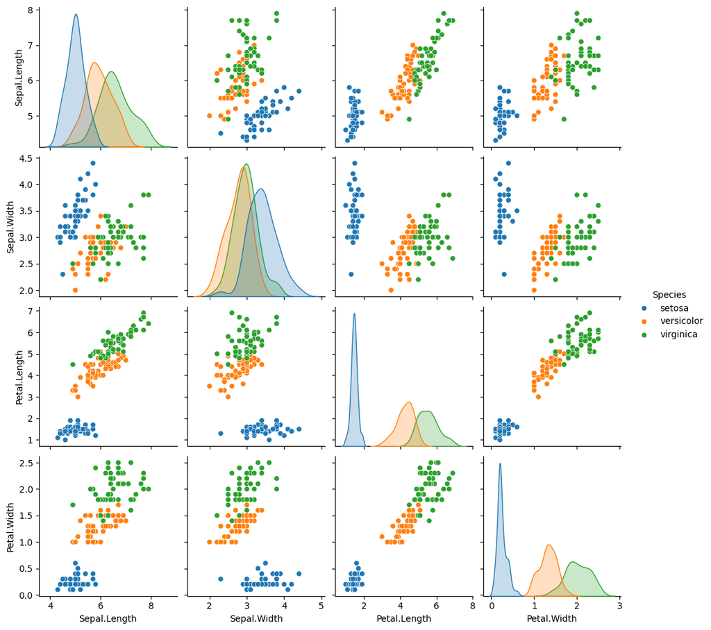

```python
sns.pairplot(Iris,hue="Species")
plt.show()
```

To explore the relationships between features, I used Seaborn's pairplot() with hue="Species" to visualize pairwise relationships in the dataset. The plot shows clear separation of 'setosa' from the other species, especially based on petal measurements, while 'versicolor' and 'virginica' show some overlap. This visualization provided insights into how distinguishable the species are, which will be useful for classification.

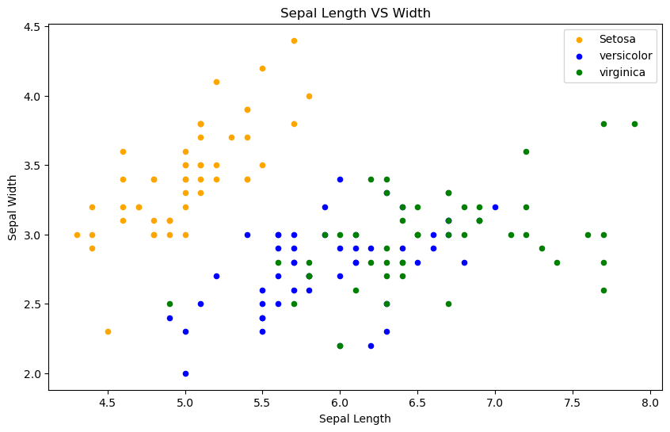

```python
fig = Iris[Iris.Species=='setosa'].plot(kind='scatter',x='Sepal.Length',y='Sepal.Width',color='orange', label='Setosa')
Iris[Iris.Species=='versicolor'].plot(kind='scatter',x='Sepal.Length',y='Sepal.Width',color='blue', label='versicolor',ax=fig)
Iris[Iris.Species=='virginica'].plot(kind='scatter',x='Sepal.Length',y='Sepal.Width',color='green', label='virginica', ax=fig)
fig.set_xlabel("Sepal Length")
fig.set_ylabel("Sepal Width")
fig.set_title("Sepal Length VS Width")
fig=plt.gcf()
fig.set_size_inches(10,6)
plt.show()
```

To visualize the relationship between sepal length and sepal width, I used a scatter plot for each species. I plotted 'Sepal.Length' on the x-axis and 'Sepal.Width' on the y-axis for 'setosa', 'versicolor', and 'virginica' species. I used different colors to differentiate between the species. The resulting plot shows that 'setosa' (in yellow) tends to have higher sepal width, while 'versicolor' and 'virginica' overlap more, making them harder to distinguish based on these two features alone. This plot helps illustrate how the sepal characteristics vary between species.

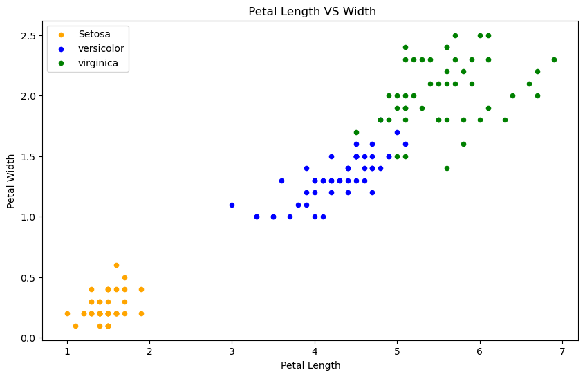

```python
fig = Iris[Iris.Species=='setosa'].plot.scatter(x='Petal.Length',y='Petal.Width',color='orange', label='Setosa')
Iris[Iris.Species=='versicolor'].plot.scatter(x='Petal.Length',y='Petal.Width',color='blue', label='versicolor',ax=fig)
Iris[Iris.Species=='virginica'].plot.scatter(x='Petal.Length',y='Petal.Width',color='green', label='virginica', ax=fig)
fig.set_xlabel("Petal Length")
fig.set_ylabel("Petal Width")
fig.set_title(" Petal Length VS Width")
fig=plt.gcf()
fig.set_size_inches(10,6)
plt.show()
```

I plotted the petal length against petal width for each of the three species in the Iris dataset. The scatter plot clearly shows that 'setosa' (in yellow) is very distinct compared to the other two species—it has much smaller petal dimensions, forming a cluster in the bottom left. In contrast, 'versicolor' (in blue) and 'virginica' (in green) overlap more, although 'virginica' tends to have larger petal measurements overall. The strong clustering of 'setosa' suggests that it is easily distinguishable based on petal size, whereas distinguishing between 'versicolor' and 'virginica' might require more complex decision boundaries due to their overlap.

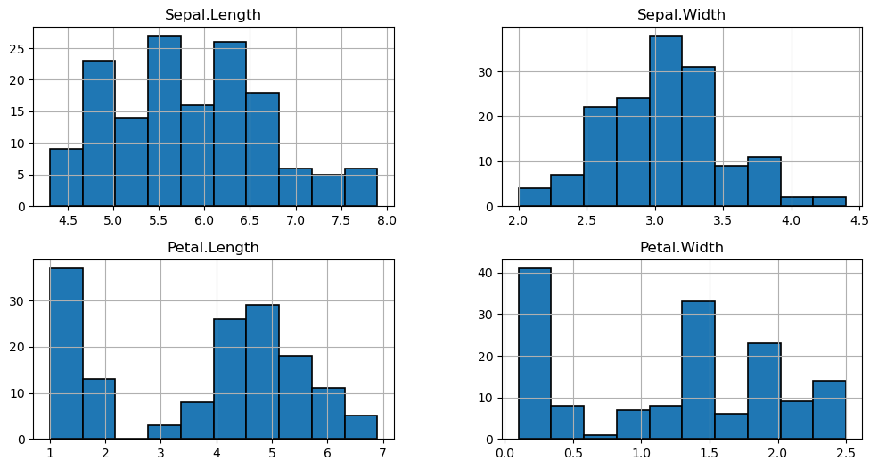

```python
Iris.hist(edgecolor='black', linewidth=1.2)
fig=plt.gcf()
fig.set_size_inches(12,6)
plt.show()
```

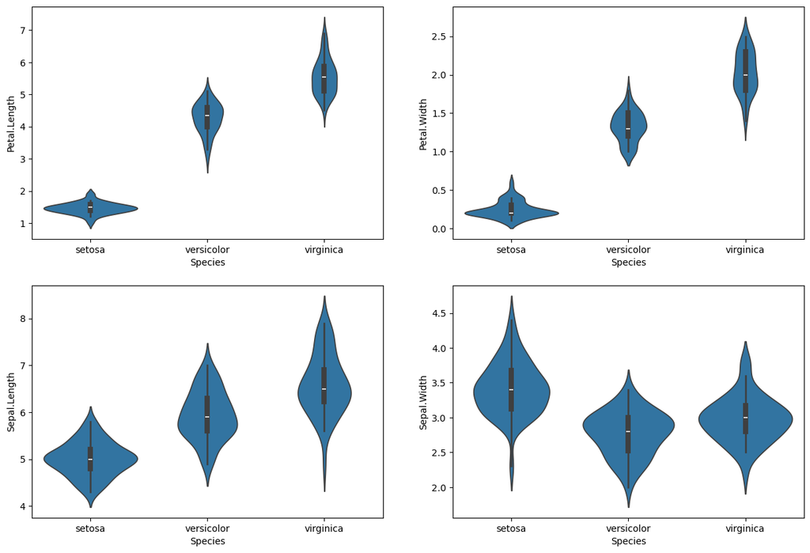

```python
plt.figure(figsize=(15,10))
plt.subplot(2,2,1)
sns.violinplot(x='Species',y='Petal.Length',data=Iris)
plt.subplot(2,2,2)
sns.violinplot(x='Species',y='Petal.Width',data=Iris)
plt.subplot(2,2,3)
sns.violinplot(x='Species',y='Sepal.Length',data=Iris)
plt.subplot(2,2,4)
sns.violinplot(x='Species',y='Sepal.Width',data=Iris)
```

I used Seaborn's violin plots to explore the distribution of the Iris dataset features across different species. These plots illustrate the distribution of petal and sepal measurements 'Petal.Length', 'Petal.Width', 'Sepal.Length', and 'Sepal.Width' for each species—'setosa', 'versicolor', and 'virginica'. The violin plots provide a combination of a boxplot and a kernel density plot, which helps in understanding both the distribution shape and spread of the data.

From the plots, I observed that 'setosa' is very distinct from the other two species, especially in petal dimensions, showing a narrow and small range. 'Versicolor' and 'virginica' tend to have more overlapping distributions, particularly in sepal measurements. However, 'virginica' often has slightly higher values compared to 'versicolor'. The overall shape of the violins shows where the data points are more concentrated, which helps me understand how each species differs in terms of these characteristics.

```python
numeric_columns = Iris[["Sepal.Length", "Sepal.Width", "Petal.Length", "Petal.Width"]]
numeric_columns.corr()
```

|  | Sepal.Length | Sepal.Width | Petal.Length | Petal.Width |
| --- | --- | --- | --- | --- |
| Sepal.Length | 1.000000 | -0.109369 | 0.871754 | 0.817954 |
| Sepal.Width | -0.109369 | 1.000000 | -0.420516 | -0.356544 |
| Petal.Length | 0.871754 | -0.420516 | 1.000000 | 0.962757 |
| Petal.Width | 0.817954 | -0.356544 | 0.962757 | 1.000000 |

I used the .corr() function to calculate the correlation matrix for the numerical features 'Sepal.Length', 'Sepal.Width', 'Petal.Length', 'Petal.Width'. This shows how these features relate to each other. The results indicate that 'Petal.Length' and 'Petal.Width' are highly correlated (0.96), while 'Sepal.Width' has weak or negative correlations with the other features. This suggests that petal measurements are closely linked, whereas sepal width varies more independently, which is important for understanding feature relationships for modeling.

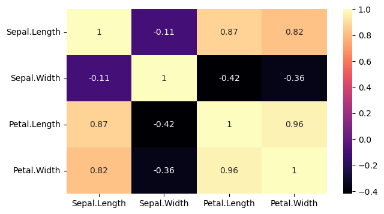

```python
# Select only the numeric columns for correlation
numeric_data = Iris.select_dtypes(include=['float64', 'int64'])

# Create a heatmap from the correlation matrix
plt.figure(figsize=(7, 4))
sns.heatmap(numeric_data.corr(), annot=True, cmap='magma')
plt.show()
```

I used the .select_dtypes() function to select only the numerical columns from the Iris dataset and created a heatmap of the correlation matrix using Seaborn's heatmap() function. The annot=True parameter displays the correlation values within each cell, and the cmap='magma' gives the plot a color gradient that helps highlight the relationships visually.

The heatmap reveals that 'Petal.Length' and 'Petal.Width' are highly correlated (0.96), while 'Sepal.Width' has low or negative correlations with the other features. This visualization makes it easier to quickly identify strong or weak relationships between the features, which is useful for understanding how each feature may impact classification.

```python
from sklearn.preprocessing import LabelEncoder
le = LabelEncoder()
Iris["Species"] = le.fit_transform(Iris["Species"])
Iris
```

|  | Sepal.Length | Sepal.Width | Petal.Length | Petal.Width | Species |
| --- | --- | --- | --- | --- | --- |
| 0 | 5.1 | 3.5 | 1.4 | 0.2 | 0 |
| 1 | 4.9 | 3.0 | 1.4 | 0.2 | 0 |
| 2 | 4.7 | 3.2 | 1.3 | 0.2 | 0 |
| 3 | 4.6 | 3.1 | 1.5 | 0.2 | 0 |
| 4 | 5.0 | 3.6 | 1.4 | 0.2 | 0 |
| ... | ... | ... | ... | ... | ... |
| 145 | 6.7 | 3.0 | 5.2 | 2.3 | 2 |
| 146 | 6.3 | 2.5 | 5.0 | 1.9 | 2 |
| 147 | 6.5 | 3.0 | 5.2 | 2.0 | 2 |
| 148 | 6.2 | 3.4 | 5.4 | 2.3 | 2 |
| 149 | 5.9 | 3.0 | 5.1 | 1.8 | 2 |

150 rows × 5 columns

To get the 'Species' column ready for modeling, I applied a LabelEncoder from sklearn.preprocessing. This allowed me to convert the categorical labels 'setosa', 'versicolor', 'virginica' into numerical values (0, 1, 2). Machine learning models generally work better with numerical data, so this step was essential for preparing the dataset. By using the .fit_transform() function, I replaced the original species labels with their respective numeric codes, making it easier for the model to interpret them while maintaining the distinction between the different classes.

```python
Iris.dtypes
```

```
Sepal.Length    float64
Sepal.Width     float64
Petal.Length    float64
Petal.Width     float64
Species           int64
dtype: object
```

## Train and Test Split

```python
x = Iris.drop(["Species"], axis=1)
y = Iris["Species"]
scaler = StandardScaler()
x_scaled = scaler.fit_transform(x)
# Update the train-test split to use normalized features
x_train, x_test, y_train, y_test = train_test_split(x_scaled, y, test_size=0.25, random_state=42, stratify=y)
```

For the train-test split, I first separated the features and the target variable. The features (x) were obtained by dropping the 'Species' column from the DataFrame, while the target (y) was simply the 'Species' column. I then used StandardScaler() to normalize the features, which ensures that all features have the same scale, improving the performance and convergence of many machine learning models. The fit_transform() method was applied to scale the features (x_scaled).

After scaling, I split the dataset into training and test sets using the train_test_split() function. I set the test size to 0.25, meaning 25% of the data will be used for testing, while the remaining 75% will be used for training. The random_state=42 ensures reproducibility, and stratify=y ensures that the class distribution is preserved in both training and test sets. This step was essential for preparing the data for model training and evaluation, ensuring a balanced representation of each class in both sets.

## Cross Validation

```python
model = DecisionTreeClassifier(random_state=42)
cv_scores = cross_val_score(model, x_train, y_train, cv=5)

# Display the cross-validation scores
print("Cross-validation scores:",cv_scores)
print("Mean CV Score:",cv_scores.mean())
```

```
Cross-validation scores: [0.86956522 0.91304348 0.95454545 1.         0.90909091]
Mean CV Score: 0.9292490118577075
```

Then to evaluate the performance of the model, I used cross-validation with a DecisionTreeClassifier. I specified random_state=42 to ensure consistent results. The cross_val_score() function was used to perform 5-fold cross-validation (cv=5) on the training data. This means that the training set was split into 5 parts, and the model was trained and evaluated on each of these parts, providing 5 separate accuracy scores.

The cross-validation scores were printed, along with the mean cross-validation score. The mean accuracy was about 0.93, indicating that the model performs quite well on average. Cross-validation helps provide a more robust measure of the model's performance by ensuring that the evaluation is not dependent on a single split of the data, reducing overfitting risks and providing a clearer picture of how the model generalizes.

## Model Training

```python
model.fit(x_train, y_train)
prediction = model.predict(x_test)
```

The next step was to train the decision tree model using the training dataset (x_train and y_train). The .fit() function was called on the model to allow it to learn from the training data. After training, I used the .predict() function to make predictions on the test data (x_test). These predictions represent the model's classification of the test samples based on what it learned during training. This step is crucial to evaluate how well the model can generalize to unseen data.

## Calculating Metrics

```python
accuracy = accuracy_score(y_test, prediction)
print("Accuracy Score",accuracy)

cm = confusion_matrix(y_test, prediction)
print("Confusion Matrix:\n", cm)
```

```
Accuracy Score 0.8947368421052632
Confusion Matrix:
 [[12  0  0]
 [ 0 12  1]
 [ 0  3 10]]
```

To evaluate the performance of my decision tree model, I calculated the accuracy score and confusion matrix. The accuracy score was obtained using the accuracy_score() function, which compares the predicted labels (prediction) with the actual labels (y_test). The model achieved an accuracy of about 89%, indicating it correctly classified the test data most of the time.

I also generated a confusion matrix using the confusion_matrix() function. The confusion matrix shows how well the model performed in classifying each species. For example, the diagonal elements (12, 12, and 10) represent the correctly classified instances for each class, while the off-diagonal values represent misclassifications. The confusion matrix helps provide a more detailed view of the model's performance, including which classes were confused with one another.

```python
# Calculate classification error
classification_error = 1 - accuracy
print("Classification Error:", classification_error)
```

```
Classification Error: 0.10526315789473684
```

To determine the classification error of my model, I computed classification_error as 1 - accuracy. This metric represents the proportion of instances the model incorrectly classified. The resulting classification error was approximately 10.5%, meaning that about 10.5% of the predictions made by the model were incorrect. Understanding the classification error is helpful for gauging the model's reliability and identifying potential areas for improvement.

## Confusion Matrix

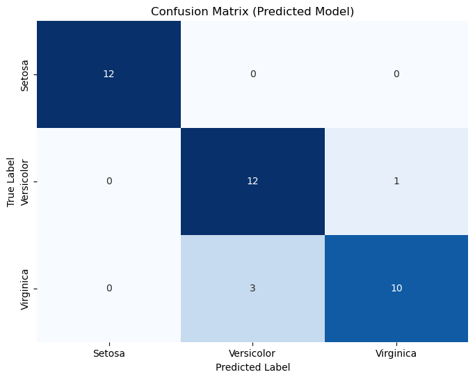

```python
plt.figure(figsize=(8, 6))

# Create the heatmap for confusion matrix
sns.heatmap(cm, annot=True, fmt='d', cmap='Blues', cbar=False,
            xticklabels=['Setosa', 'Versicolor', 'Virginica'],
            yticklabels=['Setosa', 'Versicolor', 'Virginica'])

# Add titles and labels
plt.title('Confusion Matrix (Predicted Model)')
plt.xlabel('Predicted Label')
plt.ylabel('True Label')

# Show the plot
plt.show()
```

Then I visualized the confusion matrix using a heatmap from Seaborn. This provides a clear view of how the predictions from the model compare with the true labels for each class. The heatmap was created using sns.heatmap() with annotations (annot=True) to display the exact values, and a blue color palette (cmap='Blues') for better visual distinction.

The confusion matrix shows that all 'setosa' samples were correctly classified (12 out of 12), indicating the model's strength in distinguishing this class. However, one 'versicolor' sample was misclassified as 'virginica', and three 'virginica' samples were incorrectly labeled as 'versicolor'. The visualization makes it easier to understand where the model struggles, specifically in distinguishing between 'versicolor' and 'virginica', which have more overlap in feature space compared to 'setosa'.

## Hyper-parameter Tuning

```
Best Parameters: {'criterion': 'gini', 'max_depth': None, 'min_samples_leaf': 1, 'min_samples_split': 5}
Optimized Accuracy Score: 0.9210526315789473
Optimized Confusion Matrix:
 [[12  0  0]
 [ 0 12  1]
 [ 0  2 11]]
Optimized Classification Error: 0.07894736842105265
```

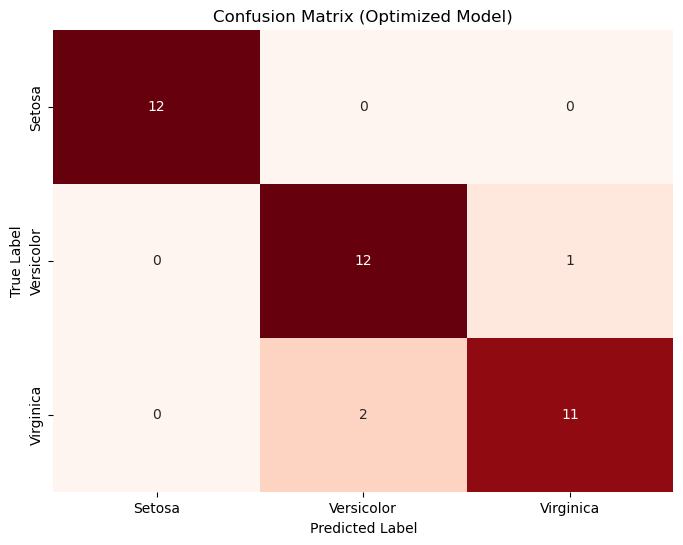

```python
# Parameter grid for optimization
param_grid = {
    'criterion': ['gini', 'entropy'],
    'max_depth': [None, 5, 10, 15],
    'min_samples_split': [2, 5, 10],
    'min_samples_leaf': [1, 2, 4]
}

# GridSearchCV with cross-validation
grid_search = GridSearchCV(DecisionTreeClassifier(random_state=42), param_grid, cv=5, n_jobs=-1, scoring='accuracy')
grid_search.fit(x_train, y_train)

# Best parameters from GridSearch
best_params = grid_search.best_params_
print("Best Parameters:", best_params)

# Train the model using the best parameters
best_model = grid_search.best_estimator_
best_model.fit(x_train, y_train)

# Evaluate the optimized model
optimized_predictions = best_model.predict(x_test)
optimized_accuracy = accuracy_score(y_test, optimized_predictions)
print("Optimized Accuracy Score:", optimized_accuracy)

optimized_cm = confusion_matrix(y_test, optimized_predictions)
print("Optimized Confusion Matrix:\n", optimized_cm)

optimized_classification_error = 1 - optimized_accuracy
print("Optimized Classification Error:", optimized_classification_error)

# Plot the confusion matrix for the optimized model
plt.figure(figsize=(8, 6))
sns.heatmap(optimized_cm, annot=True, fmt='d', cmap='Reds', cbar=False,
            xticklabels=['Setosa', 'Versicolor', 'Virginica'],
            yticklabels=['Setosa', 'Versicolor', 'Virginica'])
plt.title('Confusion Matrix (Optimized Model)')
plt.xlabel('Predicted Label')
plt.ylabel('True Label')
plt.show()
```

To optimize the performance of my decision tree model, I used GridSearchCV to search over a grid of hyperparameters. I specified a parameter grid (param_grid) that included different values for 'criterion', 'max_depth', 'min_samples_split', and 'min_samples_leaf'. The GridSearchCV function was used to find the best combination of these parameters by performing cross-validation on the training data. After fitting the grid search, I obtained the best model parameters, which were {criterion: 'gini', max_depth: None, min_samples_leaf: 1, min_samples_split: 5}.

Using these best parameters, I trained a new model (best_model) and evaluated its performance. The optimized accuracy score improved to approximately 92.1%, and the classification error decreased to around 7.9%. The optimized confusion matrix shows that most classes were correctly classified, with only a few misclassifications involving 'versicolor' and 'virginica'. Visualizing this confusion matrix helped confirm that the optimized model had a better classification capability compared to the previous one, reducing errors between overlapping classes.

The confusion matrix for the optimized model was visualized using Seaborn's heatmap, with red shades representing the frequency of predictions in each category. From the confusion matrix, it's evident that all 'setosa' samples were correctly classified, similar to before. The model made only one mistake with the 'versicolor' class, misclassifying it as 'virginica', and two errors with 'virginica', which were classified as 'versicolor'. The reduced number of misclassifications compared to the initial model highlights the improvement brought by hyperparameter tuning, particularly in differentiating between the overlapping classes of 'versicolor' and 'virginica'.

```python
# Define the scoring metrics
scoring = ['accuracy', 'precision_macro', 'recall_macro', 'f1_macro']

# Perform cross-validation with multiple metrics
cv_results = cross_validate(model, x_train, y_train, cv=5, scoring=scoring)

# Display cross-validation results
print("Cross-validation Accuracy:", cv_results['test_accuracy'].mean())
print("Cross-validation Precision:", cv_results['test_precision_macro'].mean())
print("Cross-validation Recall:", cv_results['test_recall_macro'].mean())
print("Cross-validation F1 Score:", cv_results['test_f1_macro'].mean())
```

```
Cross-validation Accuracy: 0.9292490118577075
Cross-validation Precision: 0.9347619047619048
Cross-validation Recall: 0.9297619047619048
Cross-validation F1 Score: 0.9270570279393808
```

To evaluate my decision tree model, I used cross-validation with multiple metrics, including accuracy, precision, recall, and F1 score. I used the cross_validate() function with 5-fold cross-validation (cv=5). The average cross-validation results were: accuracy of 92.9%, precision of 93.5%, recall of 92.98%, and an F1 score of 92.7%. These metrics provide a well-rounded understanding of the model's performance, showing it can accurately classify the samples while maintaining a good balance between precision and recall.

## Decision Tree Plot

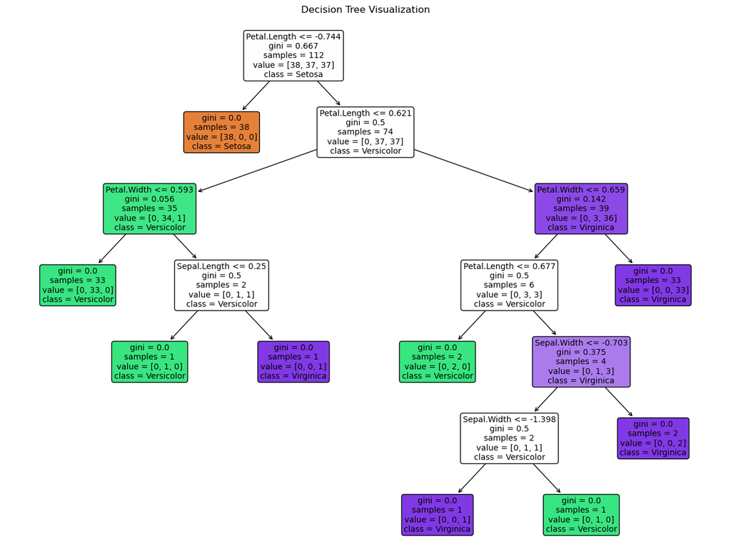

```python
# Plotting the decision tree
plt.figure(figsize=(16, 12))
plot_tree(model, feature_names=x.columns, class_names=['Setosa', 'Versicolor', 'Virginica'],
          filled=True, rounded=True, fontsize=10)

plt.title("Decision Tree Visualization")
plt.show()
```

For visualizing the decision tree, I used plot_tree() to generate a clear and interpretable visualization of my decision tree model. I set the figure size to (16, 12) for better readability, and included feature names and class names (Setosa, Versicolor, Virginica) for easy understanding. The decision tree plot provides a graphical representation of the splits at each node, including the conditions, Gini impurity values, and class labels.

The decision tree visualization provides an insight into how the model splits the dataset based on different features to classify each iris species (Setosa, Versicolor, Virginica). The root of the tree starts with Petal.Length, which is the most informative feature, used to make the first split. This split helps in differentiating Setosa from the other species since Setosa has distinctively smaller petal lengths.

As we move down the branches, further splits occur based on features like Petal.Width, Sepal.Length, and Sepal.Width. For instance, after separating Setosa, the next splits are primarily focused on distinguishing Versicolor from Virginica. Nodes in the tree show important information, such as Gini impurity (a measure of the impurity or heterogeneity at each split), the number of samples, and the value, which indicates the count of samples per class.

The leaves of the tree (nodes at the bottom) represent the final classification, where all samples belong to a single class, indicated by Gini of 0. The decision tree thus visually conveys the sequential feature splits that lead to each prediction, highlighting how petal and sepal characteristics are used to classify iris species step by step.

## Results

The results demonstrated the effectiveness of using a Decision Tree classifier for classifying iris species. The initial model achieved a cross-validation accuracy of approximately 92.9%, with precision, recall, and F1 scores around the same value, indicating balanced performance across metrics. The confusion matrix revealed that the model had some difficulty distinguishing between 'versicolor' and 'virginica,' resulting in a few misclassifications.

Overall, the results illustrate the capability of Decision Tree models for classification tasks and the impact of hyperparameter tuning on model performance. Despite some limitations in differentiating similar classes, the model performed well, demonstrating a clear improvement after optimization.

## Research

Throughout this project, I gained valuable insights into various machine learning techniques and tools that were previously unfamiliar to me. One of the key things I learned was how to plot **violin plots**. These plots were incredibly useful in visualizing the distribution of features across different classes, showing both the density and variability in an intuitive way. By understanding violin plots, I was able to better interpret how feature distributions differed among iris species.

Another significant learning was the application of the **Label Encoder** from scikit-learn. The Label Encoder helped in transforming categorical labels into numerical values, which is a crucial step when preparing data for machine learning models. This helped me understand how categorical data can be handled effectively in Python.

I also learned about feature scaling through the use of the **StandardScaler**. Scaling features is a vital preprocessing step to ensure that all features contribute equally to the model, especially when using algorithms sensitive to feature magnitude. By scaling the dataset, I ensured that none of the features dominated the learning process due to larger numerical values.

The **Decision Tree Classifier** was another new concept for me. I explored how to use decision trees for classification tasks, including how to set up and interpret the nodes and splits within the tree. I learned how decision trees split the data based on feature thresholds to create decision boundaries that classify the data accurately.

Another interesting concept I came across was the **confusion matrix**. Creating and interpreting a confusion matrix allowed me to understand the model's performance beyond just accuracy. It provided a clear view of where the model made correct predictions and where it struggled, especially when it came to distinguishing between similar classes like 'versicolor' and 'virginica.'

Finally, I delved into hyperparameter tuning through **parameter grid optimization** using GridSearchCV. This process was essential to identify the best combination of hyperparameters for my Decision Tree model, thereby improving the model’s accuracy and reducing classification errors. Understanding the concept of parameter grids and how to use them to optimize a model was an eye-opening experience that highlighted the impact of model tuning on performance.

Cited from:https://scikit-learn.org/stable/modules/tree.html#tree